# Equation audit of arm `revised`: four known defects, one new one, and what the fixes do to the calibration

The catalogue’s split rows; the 6–18% price jump at the spin-up restart, traced to the money wage (not the Sraffian globals); the Armington origin mismatch between real final demand and final imports, closed as change R10; the va_g / va_index definitions; and a numerical identity check that finds expenditure GDP and income GDP disagree whenever tariffs are non-zero.

Author

LEEDS_MODEL — JUST2CE

Published

September 29, 2026

**Written:** 2026-09-29 · **Repo at:** `main` @ `8e07250` plus this session’s uncommitted engine changes (`model/code/run_model_2026.R`, `model/code/MVP_model_2026.R` and the regenerated `flash_MVP_model_2026.R` and `model/code/arms/*`). **Baselines compared** (all `output/scenarios/arms/revised/runs/`, gitignored):

- `baseline_pre_wagecarry_20260929.RDS`: the calibrated `revised` of 28 September, before any fix;
- `baseline_wagecarry_only_20260929.RDS`: with the restart fix only;
- `baseline.RDS`, also kept as `baseline_wagecarry_r10_uncalibrated_20260929.RDS`: with the restart fix and R10. **This is now the cached `revised` baseline, and it is not calibrated.**

> **Addendum, same day: the maintainer’s decisions applied (section 8).** The `va` valuation fix (item 6 below) and chain-linked volume growth for `va_g` / `va_index` (item 7) are implemented as change **R11**. Every identity in section 4 now closes, `yn = va` included. The bank-reserve question is answered from G&L ch. 10 in section 8. The `b_cb_s_Z2` closure moves to the item-4 plan.

## Summary

1. **Split catalogue rows: fixed.**
   - *Cause:* on 15 equations one column’s note carried an arm addendum the others did not, and the page pivots on the note.
   - *Fix:* every column now carries the full note. `tools/melt_equation_tables.py` refuses to build if an equation has more than one key tuple.
   - `model/equations/model-equations.html` shows 145 equations in 145 rows.
2. **Restart price jump: cause found and fixed.**
   - *Cause:* it is not the four Sraffian globals (the hand-off’s hypothesis). It is **the money wage**. Under `price_spec = "production"` the wage is a state, but the workbook types it exogenous, so the spin-up restart did not carry it.
   - *Fix:* the restart now carries it. p(2)/p(1) = 1 to 3e-6.
3. **Armington gap: fixed as R10.** Real final demand now uses the same Armington-adjusted origin shares as the import volumes and the deflators. The engine-side mismatch falls from 5.61 to below 3e-9.
4. **The older arms are untouched.** `submitted`, `lambda` and `sraffian` re-run `identical()` to their caches: 0 of 671,300 / 671,900 / 671,900 cells differ.
5. **Consequence: `revised` must be recalibrated.** The 28 September calibration had absorbed the price jump. Without the jump:
   - the price level is 1.004 (EU) and 1.022 (RoW), where it was 1.089 and 1.188;
   - nominal value added is 0.95 and 0.85 of target;
   - the EU current account runs +6.4 per period, so the baseline is no longer stationary.
6. **New defect, not fixed: expenditure GDP ≠ income GDP when tariffs are non-zero.**
   - `yn` (eq. 2.4) is below `va` (2.4b) by 13.9 (EU, 1.3% of VA) and 12.3 (RoW, 0.4%).
   - With tariffs set to zero the difference is 4e-6.
   - Every stock–flow identity still closes, because profits are computed from `yn`. But `va` is the calibration target and the denominator of debt/VA.
7. **`va_g` / `va_index`: a decision for the maintainer (section 5), not changed.**

## 1. The catalogue’s split rows

- **What the page does.** `tools/build_equation_tables.sh` pivots `qmd/equations/equations.csv` with the row key `eq_num, eq_id, block, variable_name, dependent_variable` plus `notes`.
- **The cause.** Fifteen equations had more than one distinct note: 0.1, 2.1, 2.4, 3.3, 3.5, 3.6, 5.2, 8.1, 8.3–8.7, 8.sraffian.1 and 9.1c. Equation 8.sraffian.1 also had two dependent variables, `D.matrix` and `K.matrix`.
- **Every case had the same form, checked mechanically.** The shorter note is an exact prefix of the longer one, which adds a dated addendum (“ARM REVISED, R9 …”, “CATALOGUE CORRECTED 2026-09-28 …”). Giving every column the longest note therefore loses nothing.
- **What changed.** 131 rows of the CSV (10 equations × 9 columns, 5 × 8, and the one `revised` cell of 8.sraffian.1, whose dependent variable now names both matrices).
- **The guard.** `tools/melt_equation_tables.py` now asserts one key tuple per equation, so the split cannot silently return.

## 2. The price jump at the spin-up restart

**Observed (the hand-off’s defect 3).** In the calibrated `revised` baseline p(2)/p(1) ran from 1.059 to 1.178 across the 108 goods, and prices were flat after t = 2.

**The hypothesis tested first, and rejected.** The hand-off suspected that the restart did not carry `R_max`, `r_sraf`, `pi_std` and `p_std`, which are all 0 at t = 1. That is true, but at t = 2 `R_max` and `r_sraf` come back **exactly** at their spin-up values (0.596984 and 0.243886). Their lagged values do not drive prices.

**The measurement.** I ran the 60-period spin-up alone, then the restarted run, and listed every row whose t = 1 value differs from the spin-up’s last period. Apart from the ecological accumulators, which restart from the workbook by design, the list contained **all 108 money-wage rows `w`**.

**The mechanism.**

- **Why `w` moves.** Under `price_spec = "production"` (arms `sraffian` and `revised`) each period replaces the sectoral wages by the region’s employment-weighted mean (`MVP_model_2026.R`, eq. 6.9a). So `w` is a state variable that evolves.
- **How far it moved.** Over the spin-up it moved from 0.0333 to 0.0297 in the EU and from 0.0111 to 0.00636 in RoW.
- **Why the restart dropped it.** The carry rule in `run_model_2026.R` carries rows typed `endogenous`, and the workbook types `w` as `exogenous`. The restart therefore put the 54 sectoral workbook wages back at t = 1.
- **The size of the reset.** At t = 2 their employment-weighted mean was 0.03120 (EU, +5.0% on the spin-up’s) and 0.007498 (RoW, +17.9%).
- **Why prices jumped.** The price of production p = w ⊘ pr + (1 + r) p (A + K) is homogeneous of degree one in w. That gives the observed jump, largest in RoW.

**The fix** (`run_model_2026.R`, carry rule). When `price_spec = "production"` the restart also carries `w` and the four Sraffian globals. The code already did the same for `wage_spec = "growth"`, for the same reason.

**The fix measured on a 6-period run after the spin-up:**

- p(2)/p(1) lies in [0.999997, 1];
- w(2)/w(1) = 1 exactly;
- `R_max`, `r_sraf`, `pi_std` and `p_std` at t = 1 equal their spin-up values;
- consumption moves 701.4 → 697.7 → 695.0 at t = 1, 2, 3, where it jumped 701.4 → 725.7 → 659.3 before.

**A residual step in the consumption deflator.** `pa` still steps +0.43% (EU) and +0.15% (RoW) at t = 2, while p does not move.

- *Why:* the Armington shares are computed relative to the prices of **t = 1 of the current run** (`base$p`).
  - In the spin-up that reference is the workbook’s prices.
  - In the main run it is the spin-up’s end prices.
  - At t = 2 the adjusted shares therefore return to the stored (2011 data) shares.
- *Assessment:* a one-time re-basing, and arguably the right one. In the main run the baseline now buys exactly the data shares at the stationary prices.
- *It also removes most of the baseline Armington gap by itself* (section 3).

**What the fix does to the calibration.** Real activity is on or above target, but the nominal targets, the debt and the external balance moved:

| at t = 100 | calibrated 28 Sep (with the jump) | restart fix only | restart fix + R10 |
| --- | --- | --- | --- |
| `pa`, EU / RoW | 1.089 / 1.188 | 1.007 / 1.017 | 1.004 / 1.022 |
| nominal VA / target, EU / RoW | 1.000 / 1.001 | 0.959 / 0.847 | 0.953 / 0.853 |
| real consumption / target, EU / RoW | 1.055 / 1.017 | 1.098 / 1.005 | 1.092 / 1.007 |
| debt/VA / target, EU / RoW | 1.000 / 1.000 | 0.110 / 1.100 | 0.733 / 0.920 |
| EU current account, mean t = 76–100 | +0.01 | +7.41 | +6.36 |
| fitness (`scale = "gdp"`) | 0.00082 | 0.046 | 0.0083 |

## 3. The Armington gap: change R10

**The defect (hand-off defect 2).**

- Real final demand d (eq. 2.1) split each region’s purchases by origin with the **stored** shares β, σ, ι, ι_g.
- The final-import volumes (9.1c) and the deflators (8.4–8.6) used the **Armington-adjusted** shares (9.1e, ε = 0.626).
- So the partner output produced for a region’s final use and that region’s final imports differed.

**The fix, R10, gated to `revision_spec = "revised"`.**

- **The hoist.** The Armington block (the computation of `arm1` and `arm2`) is moved, unchanged, above d. All its inputs are predetermined within the period: the stored shares written at the top of the period, lagged p, τ, VAT and xr, and the t = 1 reference. So the move is numerically identical for every arm, and the re-runs of `submitted`, `lambda` and `sraffian` confirm it cell for cell.
- **The change.** Under R10, d reads `arm1`/`arm2`. The R9 replacement term subtracts ι̃ × da with the same adjusted ι.

**The check, made non-tautological.** `R/measure_armington_gap.R` computed the “produced” side from the stored shares by construction, so after R10 it would still report the old gap. It now also reports `engine_gap`:

- *the test:* the engine’s own d for a region’s goods, minus (home final use at the adjusted shares + the partner’s final imports as the engine computed them);
- *what it must give:* 0 when volumes and imports agree.

Baseline. `gap_stored_vs_adjusted`: final imports computed with the stored minus the adjusted shares. `engine_gap`: the engine’s d for the region’s own goods minus home use plus partner imports; it must be 0.

| run | t | region | gap_stored_vs_adjusted | engine_gap |
| --- | --- | --- | --- | --- |
| calibrated 28 Sep (no R10) | 2 | Z1 | 0.0000000000 | -0.0000056159 |
| calibrated 28 Sep (no R10) | 2 | Z2 | 0.0000000000 | -0.0000235346 |
| calibrated 28 Sep (no R10) | 70 | Z1 | 2.1262833601 | -5.6057511815 |
| calibrated 28 Sep (no R10) | 70 | Z2 | -3.4794677055 | 5.6057505722 |
| calibrated 28 Sep (no R10) | 100 | Z1 | 2.1232142952 | -5.6053306562 |
| calibrated 28 Sep (no R10) | 100 | Z2 | -3.4821163224 | 5.6053304534 |
| restart fix + R10 | 2 | Z1 | 0.0000000000 | -0.0000001142 |
| restart fix + R10 | 2 | Z2 | 0.0000000000 | -0.0000004567 |
| restart fix + R10 | 70 | Z1 | -0.0000258761 | 0.0000000000 |
| restart fix + R10 | 70 | Z2 | 0.0000407413 | -0.0000000002 |
| restart fix + R10 | 100 | Z1 | -0.0000178767 | -0.0000000007 |
| restart fix + R10 | 100 | Z2 | 0.0000277283 | -0.0000000029 |

**Under scenario 7**, re-run on the R10 engine (`output/scenarios/arms/revised/runs/shock_7_run.RDS`, on the uncalibrated baseline):

- **The pre-R10 mismatch.** At t = 100 the stored-versus-adjusted gap is +0.0092 (EU) and −0.0133 (RoW). That is the mismatch the pre-R10 engine would have produced.
- **Measured against the scenario’s own effect.** RoW’s final imports rise by 0.0175 in the scenario, so the mismatch would have been about 76% of the response.
- **With R10.** The engine gap stays at 2.5e-7 or less: 2.5e-7 at the shock period t = 70, and 2.7e-8 at t = 100. That is the Gauss–Seidel convergence tolerance, not a model gap.
- **Against the acceptance test.** At t = 70 of the scenario the gap is above the 1e-8 threshold, by solver noise only; in the baseline it is below the threshold at t = 70 and t = 100.

## 4. Numerical identity check

`R/check_identities.R` (new) evaluates the accounting identities on a cached run, period by period. Each identity closes two *different* equations against each other, so it tests something rather than restating one line of code. The table shows the largest |residual| over t = 3–100.

Largest absolute residual, t = 3–100, in 10 bn EUR.

| eq. | identity | region | calibrated 28 Sep | restart fix + R10 | + R11 |
| --- | --- | --- | --- | --- | --- |
| 1.5 | household wealth: V = V(-1) + YD - c pA | Z1 | 1.479000e-09 | 5.300000e-11 | 9.300000e-11 |
| 7.7 | household balance sheet: V + Lh = Hh + Mh + B(own) + B(foreign) + E(own) + E(foreign) | Z1 | 2.400720e-07 | 5.713000e-09 | 1.004400e-08 |
| 4.1 | loans: Ls = LF + Lh | Z1 | 3.350030e-07 | 8.046000e-09 | 1.414000e-08 |
| 4.4 | bank balance sheet: Ls + Bb = Ms + A | Z1 | 0.000000e+00 | 0.000000e+00 | 0.000000e+00 |
| 4.2 | deposits: Ms = Mh | Z1 | 1.764020e-07 | 4.216000e-09 | 7.419000e-09 |
| 5.6a | debt: Bs = Bs(-1) + DEF | Z1 | 0.000000e+00 | 0.000000e+00 | 0.000000e+00 |
| 10.2/10.3 | bill market: Bs = held by own hh + foreign hh + banks + CBs | Z1 | 0.000000e+00 | 0.000000e+00 | 0.000000e+00 |
| 3.4 | capital: k = k(-1) + id - da | Z1 | 0.000000e+00 | 0.000000e+00 | 0.000000e+00 |
| 2.4 vs 2.4b | GDP: expenditure YN = income VA | Z1 | 9.893001e+00 | 1.385937e+01 | 9.184400e-08 |
| 9.8 | NAFA = DEF + CAB (as coded) | Z1 | 0.000000e+00 | 0.000000e+00 | 0.000000e+00 |
| 1.5 | household wealth: V = V(-1) + YD - c pA | Z2 | 1.535000e-08 | 5.350000e-10 | 9.330000e-10 |
| 7.7 | household balance sheet: V + Lh = Hh + Mh + B(own) + B(foreign) + E(own) + E(foreign) | Z2 | 4.696100e-08 | 1.304000e-09 | 2.286000e-09 |
| 4.1 | loans: Ls = LF + Lh | Z2 | 2.474000e-07 | 6.999000e-09 | 1.221700e-08 |
| 4.4 | bank balance sheet: Ls + Bb = Ms + A | Z2 | 0.000000e+00 | 0.000000e+00 | 0.000000e+00 |
| 4.2 | deposits: Ms = Mh | Z2 | 9.214070e-07 | 2.625600e-08 | 4.584100e-08 |
| 5.6a | debt: Bs = Bs(-1) + DEF | Z2 | 0.000000e+00 | 0.000000e+00 | 0.000000e+00 |
| 10.2/10.3 | bill market: Bs = held by own hh + foreign hh + banks + CBs | Z2 | 0.000000e+00 | 0.000000e+00 | 0.000000e+00 |
| 3.4 | capital: k = k(-1) + id - da | Z2 | 0.000000e+00 | 0.000000e+00 | 0.000000e+00 |
| 2.4 vs 2.4b | GDP: expenditure YN = income VA | Z2 | 2.014309e+01 | 1.229886e+01 | 3.466730e-07 |
| 9.8 | NAFA = DEF + CAB (as coded) | Z2 | 0.000000e+00 | 0.000000e+00 | 0.000000e+00 |
| 9.3 | world trade: exports(Z1) = imports(Z2), real | world | 0.000000e+00 | 0.000000e+00 | 0.000000e+00 |
| 9.5 | world trade balance: TB(Z1) + xr TB(Z2) = 0 | world | 0.000000e+00 | 0.000000e+00 | 0.000000e+00 |
| 9.6 | world current account: CAB(Z1) + xr CAB(Z2) = 0 | world | 0.000000e+00 | 0.000000e+00 | 0.000000e+00 |
| 10.6 | world gold: dOR(Z1) pOR + dOR(Z2) pOR = 0 | world | 2.521349e-05 | 6.565000e-07 | 1.166201e-06 |
| run.model | run.model’s own consistency error (last iterate) | world | 3.180000e-10 | 0.000000e+00 | 1.000000e-12 |

### The new defect: expenditure GDP ≠ income GDP when tariffs are non-zero

- **The size.** `yn` (2.4, expenditure side, net of VAT and tariffs) is below `va` (2.4b, income side, Σ p∘x − (pᵀA_xr)∘x):
  - by 9.9 (EU) and 20.1 (RoW) in the calibrated run;
  - by 13.9 and 12.3 in the fixed one;
  - by about −12 / −20 already at t = 1.
- **The test.** A 4-period run without the spin-up, varying the tariff pass-through φ (the share of the duty borne by the importer) and the tariffs:

| run | EU yn − va, t = 2–4 | RoW yn − va, t = 2–4 |
| --- | --- | --- |
| φ = 0.5 (shipped) | −38.7, −13.0, −13.2 | −29.8, −17.7, −13.1 |
| φ = 1 | −20.9, −16.6, −12.3 | −31.4, −4.8, −7.7 |
| φ = 0 | −56.6, −0.1, −11.4 | −27.9, −54.8, −26.3 |
| all tariffs = 0 | 0.0000 | 0.0000 |

(The first periods without a spin-up are unsettled, hence the noise.)

- **The conclusion.** The gap exists if and only if tariffs are non-zero, and no value of φ closes it.
- ⚠️ **The mechanism, hypothesised, not yet decomposed numerically.** Two valuation terms, both making `va` too high:
  1. **exports:** with φ < 1 the exporter receives CV = xr·p(1 + φτ)/(1 + τ) < p per unit exported, but `va` counts the full p;
  2. **imported intermediates:** `va` charges them at the exporter’s price p (the `pᵀA_xr` term), not at the duty-inclusive price the importing firm pays, which `yn` (through IMP and TAR) does charge.

  The second term does not vanish at φ = 1, which fits the table.
- **Why the stock identities still close.** Firms’ profits `FF` are computed from `yn`, so every flow reaching a balance sheet is consistent. What is mis-measured is the statistic `va`. But `va` is also:
  - the calibration target;
  - the denominator of debt/VA;
  - the base of `va_j` → `int_j` (1.8) and the sectoral distribution variables.
- **Proposed fix, for a decision.** Under `revised`, compute `va_j` as revenue actually received minus intermediate inputs at the buyer prices `q_a`, so that Σ va_j = `yn`. It moves the VA target and debt/VA, so it belongs in the same recalibration.

## 5. `va_g` and `va_index`: a definition to choose

- **`rva` and `va`** (2.4c, 2.4a). `rva` is current volumes at *last period’s* prices, and `va` is current volumes at current prices.
- **So `va_g`** (2.4e) = `rva/va` − 1 = 1/P − 1, where P is the Paasche price index of value added. That is approximately **minus the inflation rate**.
- **The maintainer’s “1 − RVA/VA”** is approximately **plus** the inflation rate.
- **Neither is volume growth.** The standard chain-linked volume growth (Laspeyres at previous-period prices) is `rva_t / va_{t−1}` − 1. The matching index is `va_index_t = va_index_{t−1} · rva_t / va_{t−1}`, starting at 1.
- **`va_index` is 0 in every period** because it chains from its workbook value 0.
- **Nothing in the engine reads either variable,** so either choice changes no other variable. A change to them in `submitted` would still break that arm’s bit-for-bit contract, so it would be gated to `revised`.
- **Not changed; waiting on the choice.**

## 6. Other findings

- **Bank reserves earn nothing** (qmd/reports/2026-09-29-calibration-ratios.qmd).
  - Bank profit (4.5) has no term in A.
  - Under R7, EU banks hold 59% of deposits as zero-interest reserves and RoW banks 49%. Their profit is negative in every period.
  - The deposit rate (0.0226 EU) is also above the bill rate (0.0216).
- **The EU central bank’s RoW-bill stock is frozen at 0** (R6, 10.5).
  - G&L’s OPENFIX makes exactly this stock the moving reserve, with gold exogenous (`qmd/reports/2026-09-29-reserve-rule-and-lambda-options.qmd`).
  - R6 instead settles in gold and freezes the stock at its t = 1 value, 0.
  - A closure choice, carried to item 4 of the hand-off.
- **The durable-goods stock `dc` (12.5)** is built from the stored β, not the adjusted ones. It is an ecological accumulator, left as is and recorded here.
- **The markup rows `mu`** are not carried across the restart either. They are inert for prices: p is continuous across the restart after the fix.

## 7. What is left

1. **Decisions, all of which move the calibration targets, so one recalibration covers all:**
   - the `va` valuation fix (section 4);
   - the bank-reserve fix;
   - the `b_cb_s_Z2` closure;
   - the `va_g` definition.
2. **Recalibrate `revised`** in the order of 28 September:
   - the equity share `Z1_lambdaE0_2`, for EU CAB = 0 (`R/calibrate_revised_cab.R`);
   - the tax scales, for the VA level, and the debt endowment (`R/calibrate_revised_debt.R`). The pre-fix calibrated baseline is kept as `baseline_pre_wagecarry_20260929.RDS` for comparison.
3. **What this audit did not do.** It did not walk the text of all 145 `revised` equations against the code. It tested the accounting numerically instead: section 4 covers stock–flow consistency and one valuation identity. A text-versus-code walk of the price and trade blocks (8.x, 9.x) is still open.

## 8. Addendum: the decisions applied

### R11: value added at the prices actually received and paid, and chain-linked volume growth

**The new definition, under `revision_spec = "revised"`:**

$$va_j = p_j x_j - (p_j - xr^f\,CV^f_j)\,m^f_j - \mathbf{q}_a^{\top} A_{\cdot j}\, x_j .$$

- m^f_j is the partner’s imports of good j: intermediate, final and replacement (`import_volumes()`).
- CV^f_j is what the exporter receives per unit.
- **q_a** is the firm buyer-price vector: CIF, duty included, on partner goods.
- `rva_j` is the same expression at the previous period’s prices, on this period’s volumes.
- So `va_g` = `rva_t / va_{t−1}` − 1 is chain-linked (Laspeyres) volume growth, and `va_index` is based at 1 at t = 1 of the main run.

**Where it sits in the engine.** It is computed in the late consistent block, where the import volumes and customs values exist. The two sector readers `t_j` and `int_j` are re-solved there, because the early coded lines run ahead of them on every Gauss–Seidel sweep.

**Measured on the re-cut, still uncalibrated, baseline:**

- `yn − va` falls from 13.9 (EU) and 12.3 (RoW) to 9.2e-8 and 3.5e-7;
- `Σ va_j = va` exactly;
- VA falls by 1.3% (EU) and 0.3% (RoW);
- the debt stocks and the deficits are unchanged to four digits, because they were built on `yn` already;
- `va_index` ends at 0.992 (EU) and 1.025 (RoW), the drift of an uncalibrated baseline;
- `submitted`, `lambda` and `sraffian` are still `identical()` to their caches.

### Bank reserves: the G&L option and the realistic option

**What the engine does now (R7):**

- banks hold bills as a fixed 10% of deposits;
- advances are the residual, so a negative value is reserves;
- reserves earn nothing;
- the deposit rate is above the bill rate in the EU.

**What G&L do in Model INSOUT, ch. 10, as read in the book:**

- *Required reserves.* Banks hold a **required** reserve ρ·M in high-powered money (eq. 10.66, p. 335), which earns nothing.
- *Bills are the residual.* **Bills are the banks’ residual buffer**, B_b = M − L − H_b (10.67, 10.71, p. 337): “in the case of the banking system, Treasury bills play the role of a buffer” (p. 336).
- *Advances only as a backstop.* **Advances are only a backstop and are never negative.** Banks borrow only when their net bill holding would fall below a floor bot·M (10.69–10.70). Advances pay r_a = r_b (10.60), and that interest enters both central-bank profit (10.61) and bank profit (10.77).
- *The rate hierarchy.* G&L impose r_l > r_b > r_m, following Godley and Cripps (1983) (p. 339).
- *The deposit rate is the equilibrating instrument.* It moves so as to keep the net liquidity ratio B_b/M between bot and top (10.73–10.76, p. 338). When banks hold too many bills, r_m falls and households move out of deposits.

**Why the G&L option cannot be switched on in LEEDS today.**

- *Deposits are too large.* They are 77% (EU) and 97% (RoW) of household net wealth. They are the portfolio residual (7.7), and every behavioural λ is 0.
- *So the residual bill holding exceeds the bill supply.* If bills were the banks’ residual, EU banks would need M − L = 1,122 of bills out of a supply of 875. The EU central bank’s own-bill holding would be −548 (RoW: −2,673).
- *The mechanism that would shrink deposits is disabled.* G&L’s equilibrating mechanism, a deposit rate that moves portfolios, needs non-zero rate sensitivities, and all of them are 0.

**Correction to my earlier suggestion.** In the calibration-ratios report I suggested raising `bank_bill_ratio` to about 0.69 (EU) and 0.59 (RoW) so that advances are near 0. That is **infeasible** for the same reason: the banks would demand more bills than the government has issued.

**The realistic option.** Central banks have run floor systems since 2008.

- *The system.* Reserves are remunerated at or near the policy rate.
- *Sizes (⚠️ recalled, not checked against ECB data).* The euro area’s excess reserves were a few per cent of deposits, not tens of per cent.

The realistic option therefore has two parts:

1. **Size:** a household portfolio that holds a realistic deposit share. That is the λ design of the item-4 plan: home bias and deposit shares from data.
2. **Price:** pay interest on reserves and on advances, symmetrically, at the policy rate r*, in both bank and central-bank profit. G&L count interest on advances in both profits; LEEDS omits it.

**Why remunerating today’s stock alone would mislead.** On today’s stock, remuneration alone would move about r* × 959 ≈ 11.6 per period from the EU central bank to the banks: r* = 0.0121, on 959 of reserves. The central bank’s profit (8.9 today) would turn negative, and the transfer would appear as about 1.1% of GDP of extra deficit. That would turn an unrealistic stock into an unrealistic fiscal cost.

**Recommendation.**

- Decide the reserve regime together with the λ block in the item-4 plan, because the stock is a portfolio artefact.
- The interest term on A should be added in either regime, since both G&L and a floor system have it. It is small once the stock is realistic.

## 9. The re-calibration of `revised`

**The procedure,** in the same order as 28 September. The runs are in `output/calibration/revised_joint_search_20260929_r*.csv`: rounds 1, 3, 4, 5, 6 and 7, with round 2 lost to the failure below.

1. **Tax scales, for value added.** A scale multiplies the net income-tax rates θ_w and θ_c.
   - Measured elasticity of VA to the scale: about −0.5 (EU) and −0.42 (RoW).
   - Adopted: 0.91 (EU) and 0.66 (RoW) on the 28 September scales.
   - So the net rates are now the observed rates × 0.6756 (EU) and × 0.3673 (RoW).
2. **The EU equity share `lambdaE0_2`, for a zero EU current account.**
   - Measured slope: about 1,050 of current account per unit of the share.
   - Adopted: 0.02064 (was 0.03227).
3. **The debt endowment, for debt/VA.**
   - Adopted: 1,143.0 (EU) and −5,243.8 (RoW).
   - Measured to move debt one for one and nothing else (rounds 6 → 7).

**The values sit in the workbook,** written by `tools/add_revised_parameters.R`. A re-cut driven by the workbook alone reproduces round 7, and `lambda` and `sraffian` are still `identical()` to their caches.

**Two numerical obstacles, both in the first spin-up periods (every stock zero at t = 1):**

- **Gauss–Seidel divergence.**
  - *The failure:* at the lower tax rates t = 2 converged only at a contraction of about 0.93 per sweep, and t = 3 diverged (error 1.9e16 within 25 sweeps).
  - *The fix:* under-relaxation, `gs_relax` = 0.7, a new global parameter, 1 (off) for the older arms. Each sweep becomes s ← ω f(s) + (1 − ω) s.
  - *Its effect on the solution:* a converged period is the same solution for any ω. But debt is path-dependent (R6), and the damped iteration reaches a different fixed point in the pathological first periods. At the same parameters, activity matched to 4 digits while pre-endowment debt/VA moved from 1.17 / 0.62 to 2.46 / 0.24. The endowment was therefore calibrated at ω = 0.7.
  - *The cap:* `max.iterations` was raised to 1,000, because the damped first period needs about 900 sweeps.
- **0 × Inf.**
  - *The failure:* at t = 2 of the spin-up a region’s equity stock could be exactly 0, making the return on equity r_e = (1 − ω)FF/e_s infinite. The portfolio equations multiply the lagged r_e by λ coefficients that are 0, so every financial stock became NaN at t = 3.
  - *The fix:* a non-finite lagged r_e is now read as 0.
  - *Why no other arm moves:* the guard is inert whenever r_e is finite, and any run that had met the infinite value would have crashed.

**The result at t = 100,** from `output/calibration/calibration_ratio_cells_20260929_recalibrated.csv`:

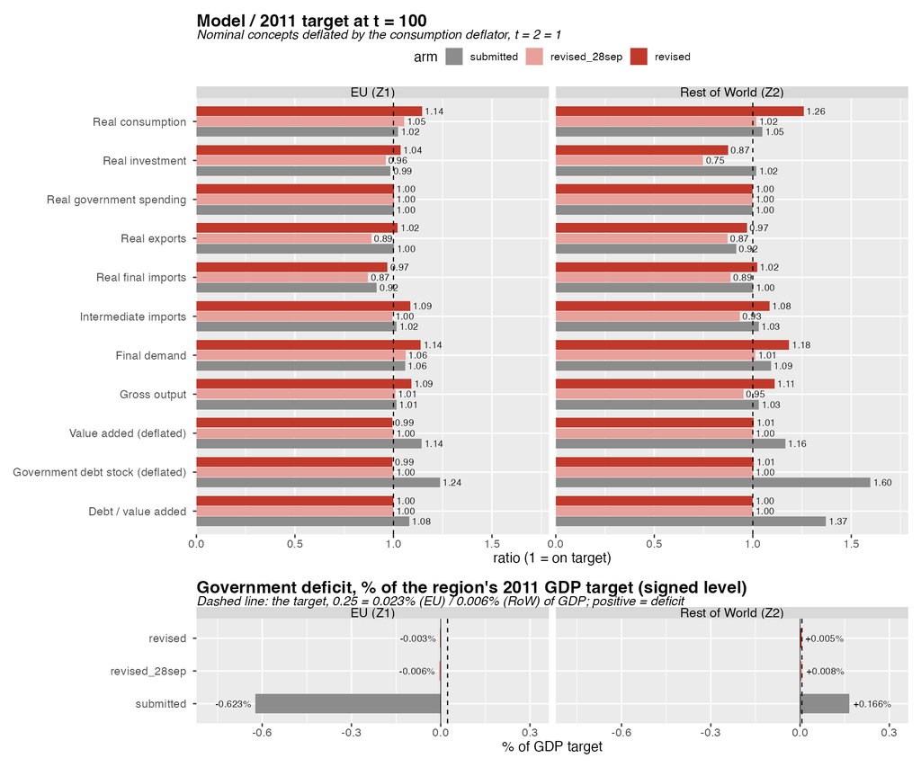

Model / 2011 target at t = 100: submitted, revised as calibrated on 28 September (with the restart artefact), and revised re-calibrated.

**Closer to the data than on 28 September:**

- exports and imports: 0.97–1.02, from 0.87–0.89;
- RoW investment: 0.87, from 0.75.

**Further from target:**

- real consumption: 1.14 (EU) and 1.26 (RoW), from 1.05 / 1.02;
- final demand: 1.14 / 1.18;
- gross output: 1.09 / 1.11.
- The fitness is 0.0074, against 0.00082 on 28 September. The old figure was flattered by the price artefact, which let nominal VA reach target with lower real volumes.

**The trade-off.** At the price level the model now reproduces (≈ 1), hitting nominal VA needs lower tax rates, and without transfers most of the extra disposable income is consumed. The model’s consumption share of VA (c·p_A/VA) is 0.67 (EU) and 0.77 (RoW), against 0.58 and 0.60 in the 2011 data.

- *The RoW net income-tax rates are 8.5% (wages) and 6.3% (capital income).*
- *The alternative:* target real consumption instead. VA would then sit below its target.
- *The structural fix:* model transfers, so that gross tax rates can stay near the observed ones.

**How settled the baseline is.** It is stationary in the limit, but still settling after the restart:

- the RoW deficit decays from 25.5 at t = 2 to 0.83 at t = 70 (the shock date) and 0.20 at t = 100;
- RoW VA rises about 3% over the run.

A longer spin-up would settle it before t = 1. It would also move the path-dependent debt level, so the endowment would need re-setting.

**Verification run:** `submitted`, `lambda`, `sraffian` re-run on the regenerated flash engine, `identical()` to their caches. `Rscript R/verify_arm_fold.R --periods 12`: all nine arms PASS, folded == switched on every cell (12-period smoke check).